# Predicting Anime Ratings

Kwesi Owubah

## Introduction:

Anime is animation that originates from Japan. It has a distinct art/drawing and/or computer animation style with Japanese voice over. In addition, there are versions of the same animation with Japanese voice overs and subtitles in various languages. Also, other voice overs exist in other languages. Although originally intended for propaganda, Anime evolved and was introduced to the world through various films and series. Today, Anime continues to grow in popularity and is often aired on international networks.

The dataset in use can be found from kaggle: https://www.kaggle.com/canggih/anime-data-score-staff-synopsis-and-genre The data from the dataset came from a very active anime and manga social networking website: https://myanimelist.net/ The webiste is used to catalog anime and manga, share details, and give scores based on user ratings.

This walkthrough goes through the data science pipline: Data collection Data Management Exploratory Analysis Hypothesis Testinga and Machine Learning Conclusions

By the end of this walkthrough you will be able to alter data into a comfortable format, apply descriptive statistics, visualize data, determine the existence of trends, and create a machine learning model to predict scores.

## Libraries

```python
# Libraries to import
import numpy as np
import pandas as pd
import matplotlib.pyplot as plt
import seaborn as sns
from sklearn import linear_model
from statsmodels.formula.api import ols
```

## Data Collection / Curation

Here is where we collect data. Data can be found from your own collection of data, websites, open databases, shared CSV files, and other sources. Again, the data from this tutorial can be found at https://www.kaggle.com/canggih/anime-data-score-staff-synopsis-and-genre. The CSV was downloaded and uploaded to a github public repository. The raw data is parsed for ease.

### Columns (Attributes) of Relation:

- Title
- Type
- Episodes
- Status
- Start Airing
- End Airing
- Starting Season
- Broadcast Time
- Producers
- Licensors
- Studios
- Sources
- Genres
- Duration
- Rating
- Score
- Scored by
- Members
- Favorites
- Description

The main data format we will be working on is a table (relation). Each row (tuple) in the relation contains data unique to an anime. We will be accumulating data from the columns (attributes) of the relation. The Table will have to be altered. There is a different scheme at play than what we would like.

The pandas data analysis library was used to read the CSV as a dataframe. This is so that we are able to parse data and perform computations more easily. Documentation can be found here: https://pandas.pydata.org/

```python
# Raw format was easier to parse
# Delimeter to separate data is a comma
data = pd.read_csv('https://raw.githubusercontent.com/Flyer107/320_Final_Tutorial/main/dataanime.csv',sep=',')
data.head()
```

|  | Title | Type | Episodes | Status | Start airing | End airing | Starting season | Broadcast time | Producers | Licensors | Studios | Sources | Genres | Duration | Rating | Score | Scored by | Members | Favorites | Description |
| --- | --- | --- | --- | --- | --- | --- | --- | --- | --- | --- | --- | --- | --- | --- | --- | --- | --- | --- | --- | --- |
| 0 | Fullmetal Alchemist: Brotherhood | TV | 64 | Finished Airing | 2009-4-5 | 2010-7-4 | Spring | Sundays at 17:00 (JST) | Aniplex,Square Enix,Mainichi Broadcasting Syst... | Funimation,Aniplex of America | Bones | Manga | Action,Military,Adventure,Comedy,Drama,Magic,F... | 24 min. per ep. | R | 9.25 | 719706 | 1176368 | 105387 | "In order for something to be obtained, someth... |
| 1 | Kimi no Na wa. | Movie | 1 | Finished Airing | 2016-8-26 | - | - | - | Kadokawa Shoten,Toho,Sound Team Don Juan,Lawso... | Funimation,NYAV Post | CoMix Wave Films | Original | Supernatural,Drama,Romance,School | 1 hr. 46 min. | PG-13 | 9.19 | 454969 | 705186 | 33936 | Mitsuha Miyamizu, a high school girl, yearns t... |
| 2 | Gintama° | TV | 51 | Finished Airing | 2015-4-8 | 2016-3-30 | Spring | Wednesdays at 18:00 (JST) | TV Tokyo,Aniplex,Dentsu | Funimation,Crunchyroll | Bandai Namco Pictures | Manga | Action,Comedy,Historical,Parody,Samurai,Sci-Fi... | 24 min. per ep. | R | 9.16 | 70279 | 194359 | 5597 | Gintoki, Shinpachi, and Kagura return as the f... |
| 3 | Steins;Gate 0 | TV | 23 | Currently Airing | 2018-4-12 | - | Spring | Thursdays at 01:35 (JST) | Nitroplus | Funimation | White Fox | Visual novel | Sci-Fi,Thriller | 23 min. per ep. | PG-13 | 9.16 | 12609 | 186331 | 1117 | The dark untold story of Steins;Gate that lead... |
| 4 | Steins;Gate | TV | 24 | Finished Airing | 2011-4-6 | 2011-9-14 | Spring | Wednesdays at 02:05 (JST) | Frontier Works,Media Factory,Movic,AT-X,Kadoka... | Funimation | White Fox | Visual novel | Sci-Fi,Thriller | 24 min. per ep. | PG-13 | 9.14 | 552791 | 990419 | 90365 | The self-proclaimed mad scientist Rintarou Oka... |

## Data Management / Representation

We will alter the table so that any missing data will have 'Nan' which is a commmon data type to represent uncommon/nonexistent/undefined values. We do this so that the processing of data is simpler and does not produce errors. Furthermore, we will remove attributes from the relation that are not required for our analysis.

This is also where we can add more columns and replace existent values for ease of future computation.

The numpy libary will be used to replace values in the table.

```python
main_rel = data.copy()

# Replace '-' with np.nan
for col in main_rel:
    main_rel[col] = main_rel[col].replace(['-'], np.nan)

# Focusing on TV, so remove all rows that do not have column value of 'TV'
main_rel = main_rel[main_rel.Type == 'TV']


genre_rel = main_rel.copy()

# Drop unused columns
main_rel = main_rel.drop(
['Status', 'End airing', 'Description'], axis = 1)


# Store only time and date time in new columns
main_rel['only_time'] = ''

# Convert everything in the columns to type string for ease of processing
main_rel['Broadcast time'] = main_rel['Broadcast time'].map(lambda x: str(x))
main_rel['Start airing'] = main_rel['Start airing'].map(lambda x: str(x))

# Create a column with just the time
for idx, row in main_rel.iterrows():
    if row['Broadcast time'] != np.nan:
        just_time = ''
        # Extract time component
        for i in range(len(row['Broadcast time'])):
            if row['Broadcast time'][i] == ':':
                just_time = row['Broadcast time'][(i-2):(i+3)]
        main_rel.at[idx, 'only_time'] = just_time

main_rel['date_time'] = np.nan

for idx, row in main_rel.iterrows():
    air_dt = pd.to_datetime('2000-01-01' + ' ' + main_rel.at[idx, 'only_time'])
    main_rel.at[idx, 'date_time'] = air_dt

main_rel['new_duration'] = np.nan

for idx, row in main_rel.iterrows():
    episode_length = row['Duration'][:2]
    main_rel.at[idx, 'new_duration'] = episode_length

main_rel.head()
```

|  | Title | Type | Episodes | Start airing | Starting season | Broadcast time | Producers | Licensors | Studios | Sources | Genres | Duration | Rating | Score | Scored by | Members | Favorites | only_time | date_time | new_duration |
| --- | --- | --- | --- | --- | --- | --- | --- | --- | --- | --- | --- | --- | --- | --- | --- | --- | --- | --- | --- | --- |
| 0 | Fullmetal Alchemist: Brotherhood | TV | 64 | 2009-4-5 | Spring | Sundays at 17:00 (JST) | Aniplex,Square Enix,Mainichi Broadcasting Syst... | Funimation,Aniplex of America | Bones | Manga | Action,Military,Adventure,Comedy,Drama,Magic,F... | 24 min. per ep. | R | 9.25 | 719706 | 1176368 | 105387 | 17:00 | 2000-01-01 17:00:00 | 24.0 |
| 2 | Gintama° | TV | 51 | 2015-4-8 | Spring | Wednesdays at 18:00 (JST) | TV Tokyo,Aniplex,Dentsu | Funimation,Crunchyroll | Bandai Namco Pictures | Manga | Action,Comedy,Historical,Parody,Samurai,Sci-Fi... | 24 min. per ep. | R | 9.16 | 70279 | 194359 | 5597 | 18:00 | 2000-01-01 18:00:00 | 24.0 |
| 3 | Steins;Gate 0 | TV | 23 | 2018-4-12 | Spring | Thursdays at 01:35 (JST) | Nitroplus | Funimation | White Fox | Visual novel | Sci-Fi,Thriller | 23 min. per ep. | PG-13 | 9.16 | 12609 | 186331 | 1117 | 01:35 | 2000-01-01 01:35:00 | 23.0 |
| 4 | Steins;Gate | TV | 24 | 2011-4-6 | Spring | Wednesdays at 02:05 (JST) | Frontier Works,Media Factory,Movic,AT-X,Kadoka... | Funimation | White Fox | Visual novel | Sci-Fi,Thriller | 24 min. per ep. | PG-13 | 9.14 | 552791 | 990419 | 90365 | 02:05 | 2000-01-01 02:05:00 | 24.0 |
| 6 | Gintama' | TV | 51 | 2011-4-4 | Spring | Mondays at 18:00 (JST) | TV Tokyo,Aniplex,Dentsu,Trinity Sound,Miracle ... | NaN | Sunrise | Manga | Action,Sci-Fi,Comedy,Historical,Parody,Samurai... | 24 min. per ep. | PG-13 | 9.11 | 90758 | 212238 | 4533 | 18:00 | 2000-01-01 18:00:00 | 24.0 |

## Exploratory Data Analysis

Next in the pipeline is where we play around with the data present. Here is where many data scientist use graphs and other forms of visualizations to find trends in data.

The new libraries in use here are matplotlib and seaborn. These libraries are used to create different kinds of statistical charts and graphs to better understand the data. Further documentation can be found here: https://matplotlib.org/ https://seaborn.pydata.org/

```
array([[<AxesSubplot:title={'center':'Score'}>]], dtype=object)
```

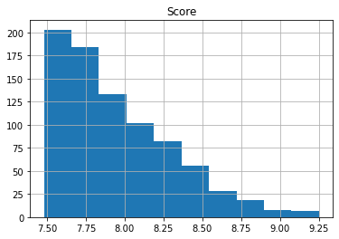

```python
main_rel.hist(column='Score')
```

Here, we can see the distribution of scores across the data. When we take it look back, the distribution appears to make sense. There would be less higher rated anime compared to the average ones. It would be interesting to see how the genre of the anime plays into the assignment of scores.

```python
import seaborn as sns
import matplotlib.pyplot as plt


# Restructure how to analyze the score dependeing on the genre
column_names = ['Genres', 'Score']

# Create a new data frame

genre_rel = pd.DataFrame(columns=column_names)
for idx, row in main_rel.iterrows():
    genre_lst = row['Genres'].split(',')

    for genre in genre_lst:
        a_row = pd.Series([genre, row['Score']])
        row_df = pd.DataFrame([a_row])
        genre_rel.loc[idx] = a_row
        genre_rel.at[idx, 'Genres'] = genre
        genre_rel.at[idx, 'Score'] = row['Score']



genre_rel
```

|  | Genres | Score |
| --- | --- | --- |
| 0 | Shounen | 9.25 |
| 2 | Shounen | 9.16 |
| 3 | Thriller | 9.16 |
| 4 | Thriller | 9.14 |
| 6 | Shounen | 9.11 |
| ... | ... | ... |
| 1555 | Magic | 7.48 |
| 1556 | Seinen | 7.48 |
| 1557 | Shounen | 7.48 |
| 1558 | Shounen | 7.48 |
| 1562 | Drama | 7.48 |

821 rows × 2 columns

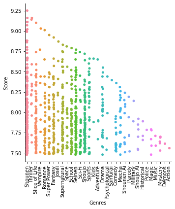

```python
import seaborn as sns

all_cols = ['Title','Type','Episodes','Start airing','Starting season','Broadcast time','Producers','Licensors','Studios','Sources','Genres', 'Duration', 'Rating','Score','Scored by','Members','Favorites','only_time','date_time']
cols_for_hist = ['Score', 'Episodes', 'Start airing', 'Starting season', 'Broadcast time' ]

def rotate_names(str):
    for ax in str.axes.flat:
        for label in ax.get_xticklabels():
            label.set_rotation(90)

catty = sns.catplot(x="Genres", y="Score", data=genre_rel)
rotate_names(catty)
```

We can get an idea of the distribution of scores based on genre from the cat plot. It is evident that genres such as Shounen, Thriller, Romance, and fantasy tend to have higher scores compared to music, mystery, and historical. In addition, we see that genres that tend to receive higher scores have high variance.

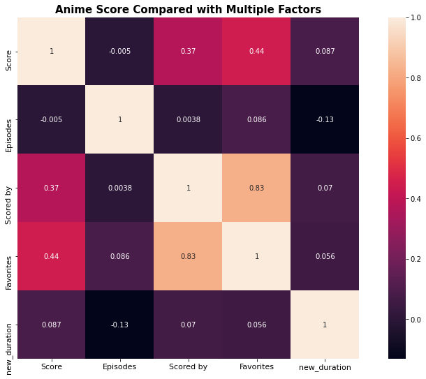

```python
# Correlation Matrix to find correlation amongst numerical values

import seaborn as sns

main_rel['Episodes'] = main_rel['Episodes'].map(lambda x: float(x))
# Build the correlation matrix
correlation_matrix = main_rel[['Score', 'Episodes', 'Scored by', 'Favorites', 'new_duration']].corr()

# Display the heatmap
plt.figure(figsize=(15, 9))
sns.heatmap(correlation_matrix, annot=True, square=True)
plt.title("Anime Score Compared with Multiple Factors", fontweight = "bold", fontsize = 15)
plt.xticks(fontsize=11)
plt.yticks(fontsize=11)
plt.show()
```

Here Pearson's standard correlation coefficient is used. In general this is a fast way to see if there is a correlation between your variables. However, it only works for numerical variables. Looking at our dataset, we have categorical variables to take into account.

If each anime was assigned 1 genre, then you could simplify this process with the ols library. Read more here: https://douglaspsteen.github.io/handling_categorical_variables_with_statsmodels_ols

## Hypothesis Testing and Machine Learning

Now we will attempt to predict the score of an anime given the factors from our table. We will do so by conducting a multiple linear regression. The response variable is numerical (score) and the predictors are a mix of categorical variables (as dummy variables) and numerical variables. It is important to note that if our response variable was categorical, a method to handle this hurdle would be to conduct a logistic regression.

Here is an article that warns us when conducting multiple linear regression. There are certain pitfalls to be careful about: https://www.kaggle.com/lukewiebolt/nhl-player-salary-multiple-regression

Ha: Betak != 0 Alternate Hypothesis: Meaning that there is some variable that is correlated with a response.

alpha = 5%

```python
from statsmodels.formula.api import ols

all_genres = ['Action', 'Military', 'Adventure', 'Comedy', 'Drama', 'Magic', 'Fantasy', 'Shounen', 'Supernatural',
              'Romance', 'School', 'Historical', 'Parody', 'Samurai', 'Sci-Fi', 'Thriller', 'Space', 'Super Power',
              'Game', 'Seinen', 'Slice of Life', 'Mystery', 'Vampire', 'Sports', 'Mecha', 'Music', 'Josei', 'Martial Arts',
              'Shoujo', 'Police', 'Psychological', 'Kids', '\xa0Adventure', 'Demons', 'Horror', 'Shounen Ai', 'Harem',
              'Cars', 'Dementia', 'Shoujo Ai']
# Creating new columns for dummy variables
regr_rel = main_rel.copy()

# Loop through all the genres and assign a default value of 0
for genre in all_genres:
    regr_rel[genre] = 0

# Loop through every anime and assign the values to be 1 if the genre is found in the genre list section
for idx, row in regr_rel.iterrows():
    genre_lst =  row['Genres'].split(',')
    for genre in genre_lst:
        regr_rel.at[idx, genre] = 1

regr_rel
```

|  | Title | Type | Episodes | Start airing | Starting season | Broadcast time | Producers | Licensors | Studios | Sources | ... | Psychological | Kids | Adventure | Demons | Horror | Shounen Ai | Harem | Cars | Dementia | Shoujo Ai |
| --- | --- | --- | --- | --- | --- | --- | --- | --- | --- | --- | --- | --- | --- | --- | --- | --- | --- | --- | --- | --- | --- |
| 0 | Fullmetal Alchemist: Brotherhood | TV | 64.0 | 2009-4-5 | Spring | Sundays at 17:00 (JST) | Aniplex,Square Enix,Mainichi Broadcasting Syst... | Funimation,Aniplex of America | Bones | Manga | ... | 0 | 0 | 0 | 0 | 0 | 0 | 0 | 0 | 0 | 0 |
| 2 | Gintama° | TV | 51.0 | 2015-4-8 | Spring | Wednesdays at 18:00 (JST) | TV Tokyo,Aniplex,Dentsu | Funimation,Crunchyroll | Bandai Namco Pictures | Manga | ... | 0 | 0 | 0 | 0 | 0 | 0 | 0 | 0 | 0 | 0 |
| 3 | Steins;Gate 0 | TV | 23.0 | 2018-4-12 | Spring | Thursdays at 01:35 (JST) | Nitroplus | Funimation | White Fox | Visual novel | ... | 0 | 0 | 0 | 0 | 0 | 0 | 0 | 0 | 0 | 0 |
| 4 | Steins;Gate | TV | 24.0 | 2011-4-6 | Spring | Wednesdays at 02:05 (JST) | Frontier Works,Media Factory,Movic,AT-X,Kadoka... | Funimation | White Fox | Visual novel | ... | 0 | 0 | 0 | 0 | 0 | 0 | 0 | 0 | 0 | 0 |
| 6 | Gintama' | TV | 51.0 | 2011-4-4 | Spring | Mondays at 18:00 (JST) | TV Tokyo,Aniplex,Dentsu,Trinity Sound,Miracle ... | NaN | Sunrise | Manga | ... | 0 | 0 | 0 | 0 | 0 | 0 | 0 | 0 | 0 | 0 |
| ... | ... | ... | ... | ... | ... | ... | ... | ... | ... | ... | ... | ... | ... | ... | ... | ... | ... | ... | ... | ... | ... |
| 1555 | Grimm Masterpiece Theater II | TV | 23.0 | 1988-10-2 | Fall | nan | NaN | Saban Entertainment | Nippon Animation | Other | ... | 0 | 1 | 0 | 0 | 0 | 0 | 0 | 0 | 0 | 0 |
| 1556 | Hidamari Sketch | TV | 12.0 | 2007-1-12 | Winter | Fridays at 01:25 (JST) | Aniplex,Lantis,TBS,Movic,Houbunsha | Sentai Filmworks | Shaft | 4-koma manga | ... | 0 | 0 | 0 | 0 | 0 | 0 | 0 | 0 | 0 | 0 |
| 1557 | Karakurizoushi Ayatsuri Sakon | TV | 26.0 | 1999-10-8 | Fall | Tuesdays at 18:30 (JST) | WOWOW | NaN | TMS Entertainment | Manga | ... | 0 | 0 | 0 | 0 | 1 | 0 | 0 | 0 | 0 | 0 |
| 1558 | Kuroshitsuji II | TV | 12.0 | 2010-7-2 | Summer | nan | Aniplex,Square Enix,Mainichi Broadcasting System | Funimation | A-1 Pictures | Manga | ... | 0 | 0 | 0 | 1 | 0 | 0 | 0 | 0 | 0 | 0 |
| 1562 | Re:␣Hamatora | TV | 12.0 | 2014-7-8 | Summer | Tuesdays at 02:05 (JST) | TV Tokyo,Sotsu,AT-X,DAX Production,NAZ,DIVE II... | Sentai Filmworks | Lerche | Original | ... | 0 | 0 | 0 | 0 | 0 | 0 | 0 | 0 | 0 | 0 |

821 rows × 60 columns

```
                            OLS Regression Results
==============================================================================
Dep. Variable:                  Score   R-squared:                       0.313
Model:                            OLS   Adj. R-squared:                  0.277
Method:                 Least Squares   F-statistic:                     8.869
Date:                Mon, 17 May 2021   Prob (F-statistic):           2.05e-41
Time:                        19:46:46   Log-Likelihood:                -183.29
No. Observations:                 821   AIC:                             448.6
Df Residuals:                     780   BIC:                             641.7
Df Model:                          40
Covariance Type:            nonrobust
=========================================================================================
                            coef    std err          t      P>|t|      [0.025      0.975]
-----------------------------------------------------------------------------------------
Intercept                 7.7449      0.039    197.414      0.000       7.668       7.822
C(Military)[T.1]         -0.0392      0.051     -0.766      0.444      -0.140       0.061
C(Adventure)[T.1]        -0.0320      0.032     -1.010      0.313      -0.094       0.030
C(Comedy)[T.1]            0.0349      0.027      1.300      0.194      -0.018       0.088
C(Drama)[T.1]             0.0855      0.025      3.391      0.001       0.036       0.135
C(Magic)[T.1]            -0.0545      0.040     -1.371      0.171      -0.133       0.024
C(Fantasy)[T.1]           0.0476      0.033      1.461      0.144      -0.016       0.112
C(Shounen)[T.1]           0.0906      0.030      3.065      0.002       0.033       0.149
C(Supernatural)[T.1]      0.0590      0.033      1.787      0.074      -0.006       0.124
C(Romance)[T.1]          -0.0379      0.029     -1.318      0.188      -0.094       0.019
C(School)[T.1]            0.0025      0.031      0.080      0.936      -0.059       0.064
C(Historical)[T.1]        0.0749      0.044      1.693      0.091      -0.012       0.162
C(Parody)[T.1]            0.1550      0.061      2.540      0.011       0.035       0.275
C(Samurai)[T.1]           0.1865      0.085      2.183      0.029       0.019       0.354
C(Sci_Fi)[T.1]           -0.0078      0.037     -0.211      0.833      -0.081       0.065
C(Thriller)[T.1]          0.0764      0.073      1.043      0.297      -0.067       0.220
C(Space)[T.1]             0.1250      0.064      1.945      0.052      -0.001       0.251
C(Super_Power)[T.1]      -0.0655      0.047     -1.390      0.165      -0.158       0.027
C(Game)[T.1]             -0.0232      0.072     -0.324      0.746      -0.164       0.117
C(Seinen)[T.1]            0.0808      0.038      2.125      0.034       0.006       0.155
C(Slice_of_Life)[T.1]     0.0418      0.030      1.384      0.167      -0.017       0.101
C(Mystery)[T.1]           0.0897      0.039      2.298      0.022       0.013       0.166
C(Vampire)[T.1]           0.0662      0.089      0.746      0.456      -0.108       0.240
C(Sports)[T.1]            0.1850      0.047      3.955      0.000       0.093       0.277
C(Mecha)[T.1]            -0.0539      0.052     -1.035      0.301      -0.156       0.048
C(Music)[T.1]            -0.0166      0.057     -0.294      0.769      -0.128       0.094
```

[output cut: 11 more lines]

```
C(Dementia)[T.1]         -0.0964      0.164     -0.590      0.556      -0.417       0.225
C(Shoujo_Ai)[T.1]        -0.0684      0.107     -0.640      0.523      -0.278       0.141
Favorites              1.502e-05   2.13e-06      7.058      0.000    1.08e-05    1.92e-05
Scored_by              1.874e-07   1.73e-07      1.083      0.279   -1.52e-07    5.27e-07
==============================================================================
Omnibus:                       38.182   Durbin-Watson:                   0.612
Prob(Omnibus):                  0.000   Jarque-Bera (JB):               42.865
Skew:                           0.516   Prob(JB):                     4.92e-10
Kurtosis:                       3.433   Cond. No.                     2.31e+06
==============================================================================

Notes:
[1] Standard Errors assume that the covariance matrix of the errors is correctly specified.
[2] The condition number is large, 2.31e+06. This might indicate that there are
strong multicollinearity or other numerical problems.
```

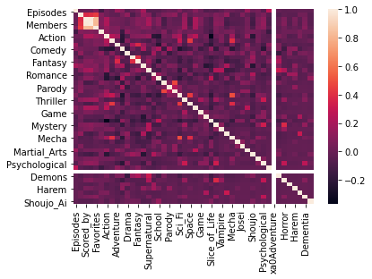

```python
regr_rel.rename(columns={'Scored by':'Scored_by', 'Super Power':'Super_Power', 'Slice of Life':'Slice_of_Life', 'Martial Arts':'Martial_Arts', 'Shounen Ai':'Shounen_Ai', 'Shoujo Ai':'Shoujo_Ai', 'Sci-Fi':'Sci_Fi', '\xa0Adventure':'xa0Adventure'}, inplace=True)

regr_formula_dummy = 'C(Action) + C(Military) + C(Adventure) + C(Comedy) + C(Drama) + C(Magic) + C(Fantasy) + C(Shounen) + C(Supernatural) + C(Romance) + C(School) + C(Historical) + C(Parody) + C(Samurai) + C(Sci-Fi) + C(Thriller) + C(Space) + C(Super Power) + C(Game) + C(Seinen) + C(Slice of Life) + C(Mystery) + C(Vampire) + C(Sports) + C(Mecha) + C(Music) + C(Josei) + C(Martial Arts) + C(Shoujo) + C(Police) + C(Psychological) + C(Kids) + C(\xa0Adventure) + C(Demons) + C(Horror) + C(Shounen Ai) + C(Harem) + C(Cars) + C(Dementia) + C(Shoujo Ai) '

fit5 = ols('Score ~ Favorites + Scored_by + C(Military) + C(Adventure) + C(Comedy) + C(Drama) + C(Magic) + C(Fantasy) + C(Shounen) + C(Supernatural) + C(Romance) + C(School) + C(Historical) + C(Parody) + C(Samurai) + C(Sci_Fi) + C(Thriller) + C(Space) + C(Super_Power) + C(Game) + C(Seinen) + C(Slice_of_Life) + C(Mystery) + C(Vampire) + C(Sports) + C(Mecha) + C(Music) + C(Josei) + C(Martial_Arts) + C(Shoujo) + C(Police) + C(Psychological) + C(Kids) + C(xa0Adventure) + C(Demons) + C(Horror) + C(Shounen_Ai) + C(Harem) + C(Cars) + C(Dementia) + C(Shoujo_Ai)', data=regr_rel).fit()

print(fit5.summary())



corrMatrix = regr_rel.corr()
sns.heatmap(corrMatrix)
plt.show()
```

The Ordinary Least Squares regression was conducted. There was a warning underneath the regression that there might be multicollinearity. Therefore, another heatmap was created to check if any of the independent variables (independent to independent, not independent to dependent) were strongly correlated with each other. The output shows that the R-Squared is 0.313. So about 31.3% of the response is explained by the predictors. In statistics R-squared over 90% is excellent. R-squared over 70% is typically acceptable. Anything underneath 40% is regarded as a low correlation. The value of the R-Squared we obtained is not that great. However, looking at the t-test in reference to the p-value (P > |t|) we see that a few of the predictors respect our confidence level of 5%.

With these categorical variables, it can be difficult to work with the data. We can reduce our output and question whether is an anime is good or not based on the factors in the data. One good way is to build a tree so that it could determine if so. A classification tree would be excellent for such a task. Read more about it here: https://www.datacamp.com/community/tutorials/decision-tree-classification-python

## Communication of Insights

Back to numbers again, we can look at the p-values (probability that the observed data shows that the null hypothesis is true) of certain predictors. We see that a few fall below 0.05 (alpha) and can conclude that there are a few predicotrs that can significantly (according to the level we selected) explain the response.